# Text Analytics part 1: Introduction to R for Text Analysis

Martin Schweinberger and Sam Hames

ResBazQld2024

[figure not shown]

# Introduction

This workshop shows how to get started with R and it specifically focuses on R for analyzing language data but it offers valuable information for anyone who wants to get started with R. As such, this workshop is aimed at fresh users or beginners with the aim of showcasing how to set up a R session in RStudio, how to set up R projects, and how to do basic operations on text using R.

The goals of this workshop are:

- How to get started with R
- How to orient yourself to R and RStudio
- Understand the basics of working with text data: loading and saving text data, cleaning text data, and creating simple plots

The intended audience for this workshop is beginner-level, with no or little previous experience using R. Thus, no prior knowledge of R is required.

## Installing R and RStudio

- You have NOT yet installed **R** on your computer?
  - You have a Windows computer? Then click [here](https://cran.r-project.org/bin/windows/base/R-4.0.2-win.exe) for downloading and installing R
  - You have a Mac? Then click [here](https://cran.r-project.org/bin/macosx/R-4.0.2.pkg) for downloading and installing R
- You have NOT yet installed **RStudio** on your computer?
  - Click [here](https://rstudio.com/products/rstudio/download/#download) for downloading and installing RStudio.

You can find a more elaborate explanation of how to download and install R and RStudio [here](https://gitlab.com/stragu/DSH/blob/master/R/Installation.md) that was created by the UQ library.

# Preparation

Before you actually open R or RStudio, there things to consider that make working in R much easier and give your workflow a better structure.

Imagine it like this: when you want to write a book, you could simply take pen and paper and start writing *or* you could think about what you want to write about, what different chapters your book would consist of, which chapters to write first, what these chapters will deal with, etc. The same is true for R: you could simply open R and start writing code *or* you can prepare you session and structure what you will be doing.

## Folder Structure and R projects

Before actually starting with writing code, you should prepare the session by going through the following steps:

### 1. Create a folder for your project

In that folder, create the following sub-folders (you can, of course, adapt this folder template to match your needs)

- data (you do not create this folder for the present workshop as you can simply use the data folder that you downloaded for this workshop instead)
- images
- tables
- docs

The folder for your project could look like the the one shown below.

[figure not shown]

Once you have created your project folder, you can go ahead with RStudio.

### 2. Open RStudio

This is what RStudio looks like when you first open it:

[figure not shown]

In RStudio, click on `File`

[figure not shown]

You can use the drop-down menu to create a `R project`

### 3. R Projects

In RStudio, click on `New Project`

[figure not shown]

Next, confirm by clicking `OK` and select `Existing Directory`.

Then, navigate to where you have just created the project folder for this workshop.

[figure not shown]

Once you click on `Open`, you have created a new `R project`

### 4. R Notebooks

In this project, click on `File`

[figure not shown]

Click on `New File` and then on `R Notebook` as shown below.

[figure not shown]

This `R Notebook` will be the file in which you do all your work.

### 5. Getting started with R Notebooks

You can now start writing in this R Notebook. For instance, you could start by changing the title of the R Notebook and describe what you are doing (what this Notebook contains).

Below is a picture of what this document looked like when I started writing it.

[figure not shown]

When you write in the R Notebook, you use what is called `R Markdown` which is explained below.

## R Markdown

The Notebook is an [R Markdown document](http://rmarkdown.rstudio.com/): a Rmd (R Markdown) file is more than a flat text document: it’s a program that you can run in R and which allows you to combine prose and code, so readers can see the technical aspects of your work while reading about their interpretive significance.

You can get a nice and short overview of the formatting options in R Markdown (Rmd) files [here](https://rstudio.com/wp-content/uploads/2015/02/rmarkdown-cheatsheet.pdf).

R Markdown allows you to make your research fully transparent and reproducible! If a couple of years down the line another researcher or a journal editor asked you how you have done your analysis, you can simply send them the Notebook or even the entire R-project folder.

As such, Rmd files are a type of document that allows to

- include snippets of code (and any outputs such as tables or graphs) in plain text while
- encoding the *structure* of your document by using simple typographical symbols to encode formatting (rather than HTML tags or format types such as *Main header* or *Header level 1* in Word).

Markdown is really quite simple to learn and these resources may help:

- The [Markdown Wikipedia page](https://en.wikipedia.org/wiki/Markdown) includes a very handy chart of the syntax.
- John Gruber developed Markdown and his [introduction to the syntax](https://daringfireball.net/projects/markdown/syntax) is worth browsing.
- This [interactive Markdown tutorial](http://www.markdowntutorial.com/) will teach you the syntax in a few minutes.

# R and RStudio Basics

RStudio is a so-called IDE - Integrated Development Environment. The interface provides easy access to R. The advantage of this application is that R programs and files as well as a project directory can be managed easily. The environment is capable of editing and running program code, viewing outputs and rendering graphics. Furthermore, it is possible to view variables and data objects of an R-script directly in the interface.

## RStudio: Panes

The GUI - Graphical User Interface - that RStudio provides divides the screen into four areas that are called **panes**:

1. File editor
2. Environment variables
3. R console
4. Management panes (File browser, plots, help display and R packages).

The two most important are the R console (bottom left) and the File editor (or Script in the top left). The Environment variables and Management panes are on the right of the screen and they contain:

- **Environment** (top): Lists all currently defined objects and data sets
- **History** (top): Lists all commands recently used or associated with a project
- **Plots** (bottom): Graphical output goes here
- **Help** (bottom): Find help for R packages and functions. Don’t forget you can type `?` before a function name in the console to get info in the Help section.
- **Files** (bottom): Shows the files available to you in your working directory

These RStudio panes are shown below.

[figure not shown]

### R Console (bottom left pane)

The console pane allows you to quickly and immediately execute R code. You can experiment with functions here, or quickly print data for viewing.

To use R more fully, we need to understand **objects**, **functions**, and **indexing** - which we will learn about as we go.

For now, think of *objects as nouns* and *functions as verbs*.

## Running commands from a script

To run code from a script, insert your cursor on a line with a command, and press `CTRL/CMD+Enter`.

Or highlight some code to only run certain sections of the command, then press `CTRL/CMD+Enter` to run.

Alternatively, use the `Run` button at the top of the pane to execute the current line or selection (see below).

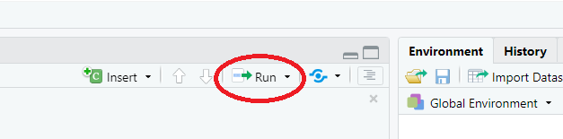

### Script Editor (top left pane)

In contrast to the R console, which quickly runs code, the Script Editor (in the top left) does not automatically execute code. The Script Editor allows you to save the code essential to your analysis. You can re-use that code in the moment, refer back to it later, or publish it for replication.

Now, that we have explored RStudio, we are ready to get started with R!

# Getting started with R

This section introduces some basic concepts and procedures that help optimize your workflow in R.

## Setting up an R session

At the beginning of a session, it is common practice to define some basic parameters. This is not required or even necessary, but it may just help further down the line. This session preparation may include specifying options. In the present case, we

- want R to show numbers as numbers up to 100 decimal points (and not show them in mathematical notation (in mathematical notation, 0.007 would be represented as 0.7e<sup>-3</sup>))
- want R to show maximally 100 results (otherwise, it can happen that R prints out pages-after-pages of some numbers).

Again, the session preparation is not required or necessary but it can help avoid errors.

```r
# set options
options(stringsAsFactors = F)
options(scipen = 100)
options(max.print=100)
```

In script editor pane of RStudio, this would look like this:

[figure not shown]

## Packages

When using R, most of the functions are not loaded or even installing automatically. Instead, most functions are in contained in what are called **packages**.

R comes with about 30 packages (“base R”). There are over 10,000 user-contributed packages; you can discover these packages online. A prevalent collection of packages is the Tidyverse, which includes ggplot2, a package for making graphics.

Before being able to use a package, we need to install the package (using the `install.packages` function) and load the package (using the `library` function). However, a package only needs to be installed once(!) and can then simply be loaded. When you install a package, this will likely install several other packages it depends on. You should have already installed tidyverse before the workshop.

```r
install.packages("tidyverse")
install.packages("tidytext")
install.packages("quanteda")
install.packages("tokenizers")
install.packages("here")
install.packages("flextable")
# install klippy for copy-to-clipboard button in code chunks
install.packages("remotes")
remotes::install_github("rlesur/klippy")
```

To load these packages, use the `library` function which takes the package name as its main argument.

```r
library(tidyverse)
library(tidytext)
library(quanteda)
library(tokenizers)
library(here)
library(flextable)
# activate klippy for copy-to-clipboard button
klippy::klippy()
```

The session preparation section of your Rmd file will thus also state which packages a script relies on.

[figure not shown]

## Getting help

When working with R, you will encounter issues and face challenges. A very good thing about R is that it provides various ways to get help or find information about the issues you face.

To get help regrading what functions a package contains, which arguments a function takes or to get information about how to use a function, you can use the `help` function or the `apropos`. function or you can simply type a `?` before the package or two `??` if this does not give you any answers.

```r
help(tidyverse)
apropos("tidyverse")
?require
```

There are also other “official” help resources from R/RStudio.

- Read official package documentation, see vignettes, e.g., Tidyverse https://cran.r-project.org/package=tidyverse
- Use the RStudio Cheat Sheets at https://www.rstudio.com/resources/cheatsheets/
- Use the RStudio Help viewer by typing `?` before a function or package
- Check out the keyboard shortcuts `Help` under `Tools` in RStudio for some good tips

# Working with text

## Loading and saving text(s)

### Loading and saving a single text

```r
# Read the lines of text from the "english.txt" file
# The `readLines` function reads each line from the specified file as a character vector
# The `here` function is used to construct a file path to the "english.txt" file in the "data" directory
text1 <- base::readLines(here::here("data", "english.txt")) %>%

  # Collapse the character vector into a single string with no spaces between lines
  paste0(collapse = "")

# Inspect the structure of the resulting text data to confirm it has been collapsed into a single string
str(text1)
```

```
##  chr "Linguistics is the scientific study of language and it involves the analysis of language form, language meaning"| __truncated__
```

To save text data, we can use the writeLines function as shown below.

```r
# Write the contents of the `text1` variable to a new text file
# The `writeLines` function saves the character data in `text1` to a file
# The `here` function is used to specify the file path within the "data" directory, naming the file "english_new.txt"
writeLines(text1, here::here("data", "english_new.txt"))
```

### Loading and saving many texts

When dealing with text data, it is quite common to encounter scenarios where we need to load multiple files containing texts. In such cases, we typically begin by storing the file locations in an object (referred to as `fls` in this context) and then proceed to load the files using the `sapply` function, which allows for looping. Within the `sapply` function, we have the option to utilize either `scan` or `writeLines` for reading the text. In the example below, we employ scan and subsequently merge the individual elements into a single text using the `paste` function. The output demonstrates the successful loading of 7 txt files from the `testcorpus` located within the `data` folder.

```r
# Extract file paths for all text files in the "testcorpus" directory
# `list.files` lists all files in the specified directory (constructed using `here::here`)
# The `pattern = "txt"` argument filters for files with a ".txt" extension
# `full.names = T` returns the full path for each file, making it easier to load them later
fls <- list.files(here::here("data", "testcorpus"), pattern = "txt", full.names = TRUE)

# Load the text from each file path into a character vector
# `sapply` applies a function to each element of `fls`, here loading each file's content
# `scan` reads the file contents as individual words (specified by `what = "char"`)
# `paste0` then collapses each file's content into a single string separated by spaces
txts <- sapply(fls, function(x){
  x <- scan(x, what = "char") %>%
    paste0(collapse = " ")
})

# Inspect the structure of `txts` to verify it contains the loaded text from each file
# `str` provides an overview of the structure and content in `txts`
str(txts)
```

```
##  Named chr [1:7] "Linguistics is the scientific study of language. It involves analysing language form language meaning and langu"| __truncated__ ...
##  - attr(*, "names")= chr [1:7] "C:/Users/uqmschw5/OneDrive - The University of Queensland/Desktop/LDaCA/ResBaz2024/data/testcorpus/linguistics01.txt" "C:/Users/uqmschw5/OneDrive - The University of Queensland/Desktop/LDaCA/ResBaz2024/data/testcorpus/linguistics02.txt" "C:/Users/uqmschw5/OneDrive …
```

```r
# Define the output file paths for each file in the sequence
# The `file.path` function constructs the paths dynamically by pasting together:
#   - the base directory using `here::here()`
#   - the "data/testcorpus_new" subdirectory
#   - the "text" prefix and sequence numbers (1 through 7) for each file
#   - the ".txt" extension to indicate text files
outs <- file.path(paste(here::here(), "/", "data/testcorpus_new", "/", "text", 1:7, ".txt", sep = ""))

# Save each text element from `txts` into the corresponding file path defined in `outs`
# `lapply` iterates over each element of `txts` using `seq_along` to get the index `i`
# `writeLines` writes the content of `txts[[i]]` (each element in `txts`) to `outs[i]`, the corresponding file path
lapply(seq_along(txts), function(i)
       writeLines(txts[[i]],
       con = outs[i]))
```

## Basics of regular expressions

Before we delve into data cleaning, we will have a look at the regular expressions that can be used in R and also check what they stand for.

There are three basic types of regular expressions:

- regular expressions that stand for individual symbols and determine frequencies
- regular expressions that stand for classes of symbols
- regular expressions that stand for structural properties

The regular expressions below show the first type of regular expressions, i.e. regular expressions that stand for individual symbols and determine frequencies.

Table 1: Regular expressions that stand for individual symbols and determine frequencies.

[output not shown]

The regular expressions below show the second type of regular expressions, i.e. regular expressions that stand for classes of symbols.

Table 2: Regular expressions that stand for classes of symbols.

| RegEx Symbol/Sequence | Explanation |
| --- | --- |
| [ab] | lower case a and b |
| [a-z] | all lower case characters from a to z |
| [AB] | upper case a and b |
| [A-Z] | all upper case characters from A to Z |
| [12] | digits 1 and 2 |
| [0-9] | digits: 0 1 2 3 4 5 6 7 8 9 |
| [:digit:] | digits: 0 1 2 3 4 5 6 7 8 9 |
| [:lower:] | lower case characters: a–z |
| [:upper:] | upper case characters: A–Z |
| [:alpha:] | alphabetic characters: a–z and A–Z |
| [:alnum:] | digits and alphabetic characters |
| [:punct:] | punctuation characters: . , ; etc. |
| [:graph:] | graphical characters: [:alnum:] and [:punct:] |
| [:blank:] | blank characters: Space and tab |
| [:space:] | space characters: Space, tab, newline, and other space characters |

The regular expressions that denote classes of symbols are enclosed in `[]` and `:`. The last type of regular expressions, i.e. regular expressions that stand for structural properties are shown below.

Table 3: Regular expressions that stand for structural properties.

| RegEx Symbol/Sequence | Explanation |
| --- | --- |
| \\w | Word characters: [[:alnum:]_] |
| \\W | No word characters: [^[:alnum:]_] |
| \\s | Space characters: [[:blank:]] |
| \\S | No space characters: [^[:blank:]] |
| \\d | Digits: [[:digit:]] |
| \\D | No digits: [^[:digit:]] |
| \\b | Word edge |
| \\B | No word edge |
| < | Word beginning |
| > | Word end |
| ^ | Beginning of a string |
| $ | End of a string |

Now that we have a basic understanding of regular expressions, we can continue with cleaning our data.

## Cleaning text data

To see how we can clean data, we will load some data representing speech of Donald Trump.

```r
# Load the text from the "Trump.txt" file line by line
# `readLines` reads each line of text from the file as a character vector
# The `here` function helps specify the file path in the "data" directory
Trump <- base::readLines(here::here("data", "Trump.txt")) %>%

  # Collapse the character vector into a single continuous string
  # `paste0(collapse = "")` removes any line breaks between lines
  paste0(collapse = "")

# Replace newline characters with a space
Trump %>%
  # remove numbers
  stringr::str_remove_all("\\d") %>%
  # Replace all non-alphanumeric characters with a space
  # Replace all non-alphanumeric characters with a space
  stringr::str_replace_all("[^[:alnum:] ']", " ") %>%
  stringr::str_replace_all("n t ", "nt ") %>%
  # Remove all double quote characters
  stringr::str_remove_all("\"") %>%
  # Remove extra whitespace and collapse multiple spaces into a single space
  stringr::str_squish()  %>%
# convert to lower case
  tolower() -> Trump_clean

# Check the character count of each element in the cleaned data
str(Trump_clean)
```

```
##  chr "speech thank you so much that's so nice isn't he a great guy he doesn't get a fair press he doesn't get it it's"| __truncated__
```

## Tabulating text data

It is very easy to extract frequency information and to create frequency lists. We can do this by first using the `unnest_tokens` function which splits texts into individual words, an then use the `count` function to get the raw frequencies of all word types in a text.

```r
# Convert the `Trump_clean` text data into a tibble format
# The `tibble` function creates a tibble with a single column named `text` containing the entire Trump text
Trump_clean %>%
  tibble::tibble(text = .) %>%

  # Use `unnest_tokens` to split the text into individual words
  # Specify `ngrams` as the token type with `n=1` to break the text down into single words (unigrams)
  # Each word will appear in a new row within the `word` column
  tidytext::unnest_tokens(word, text, token = "ngrams", n = 1) %>%

  # Count the occurrences of each unique word and sort the counts in descending order
  # The resulting data frame will have two columns: `word` and `n` (the count of each word)
  dplyr::count(word, sort = TRUE)  %>%

  # Display the top 10 most frequent words
  head(10)
```

```
## # A tibble: 10 × 2
##    word      n
##    <chr> <int>
##  1 i      6155
##  2 the    5924
##  3 to     5460
##  4 and    5437
##  5 we     3774
##  6 a      3595
##  7 it     3549
##  8 you    3476
##  9 they   3008
## 10 of     2953
```

## Visualising frequency lists

```r
# Convert the text into a tibble (a type of data frame) with one column named 'text'
Trump_clean %>%
  tibble::tibble(text = .) %>%
  # Break the text into individual words (using ngrams with n=1 means single words)
  tidytext::unnest_tokens(word, text, token = "ngrams", n = 1) %>%
  # Count the occurrences of each word and sort them in descending order
  dplyr::count(word, sort = TRUE) %>%
  # Keep only the top 10 most frequent words
  head(20) -> freq_tb  # Store the result in freq_tb
```

The next chunk creates a simple bar chart using the `ggplot2` package to visualize the word frequencies stored in `freq_tb.` The x-axis represents the words, while the y-axis represents the counts (frequency) of each word. The `geom_bar()` function is used with `stat = "identity"` to display the actual counts as bar heights.

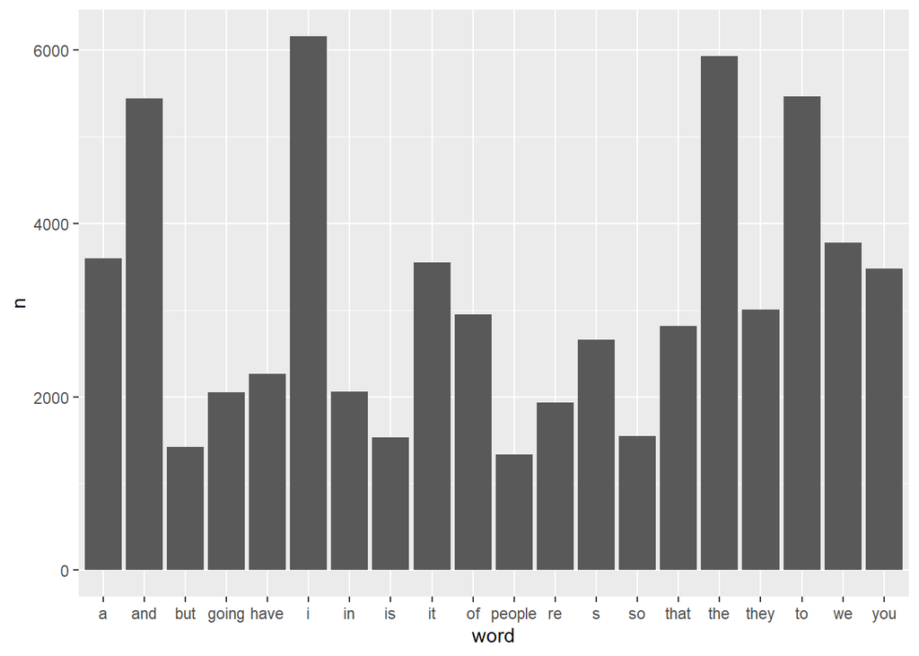

```r
# Create a bar chart to visualize the frequency of the top words
ggplot(freq_tb, aes(x = word, y = n)) +
  # Use bars to represent the counts of each word
  geom_bar(stat = "identity")
```

This chunk creates a more visually appealing horizontal bar chart of the word frequencies. The ggplot() function is used to set up the plot, with reorder() ensuring that the words are arranged according to their frequencies. Bars represent the counts, and text labels displaying the frequency are positioned slightly above each bar. The coord_flip() function flips the axes to make the bars horizontal. Additional formatting, such as titles, axis labels, and a clean theme, is applied to enhance the chart’s readability, and the legend is removed for clarity.

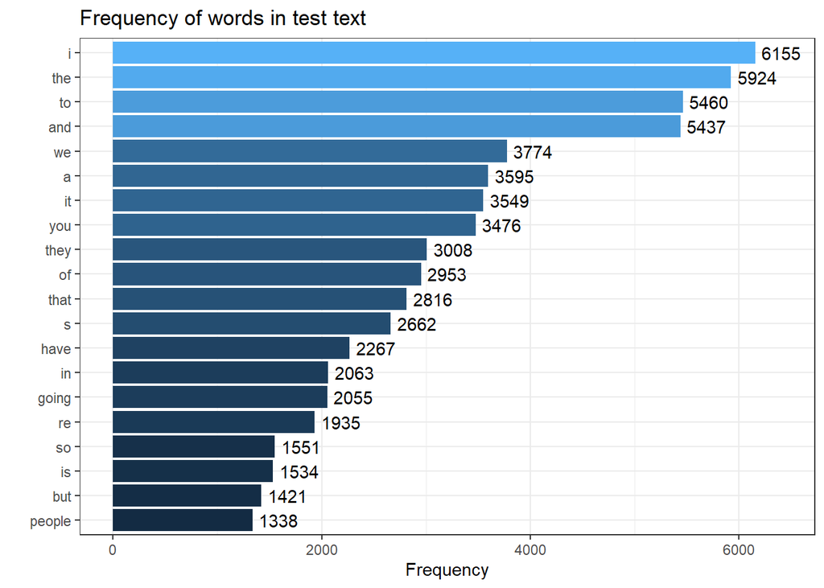

```r
# Create a more detailed horizontal bar chart with word frequencies
ggplot(freq_tb, aes(x = reorder(word, n), y = n, label = n, fill = n)) +
  # Use bars to represent the counts of each word
  geom_bar(stat = "identity") +
  # Add text labels to the bars showing their counts, offset slightly above the bars
  geom_text(aes(y = n + 250)) +
  # Flip the coordinates to make the bars horizontal
  coord_flip() +
  # Add titles and labels to the chart
  labs(title = "Frequency of words in test text",
       x = "",
       y = "Frequency") +
  # Use a clean theme for the chart
  theme_bw() +
  # Remove the legend from the chart
  theme(legend.position = "none")
```